# Time Series: A First Course with Bootstrap Starter

# Lesson 8-1: Introduction to Entropy

- We introduce **entropy** as a measure of randomness and unpredictability.
- Modeling time series involves increasing the entropy, to where we cannot predict anything.

## Definition 8.1.8.

- The **entropy** of a discrete random variable $X$ is denoted $H(X)$:
  $$H(X) = - \sum_k {\mathbb P}[ X = k] \, \log ({\mathbb P}[ X = k]).$$
- This is non-negative, with higher values corresponding to greater uncertainty.
- A value of zero corresponds to $X$ being deterministic almost surely.

## Example 8.1.10. Bernoulli Entropy

- Let $X$ be a Bernoulli random variable with success probability $p$. The entropy is
  $$-( p \log p + (1-p) \log (1-p)).$$
- Entropy is highest for $p=1/2$, and lowest for $p=0,1$.

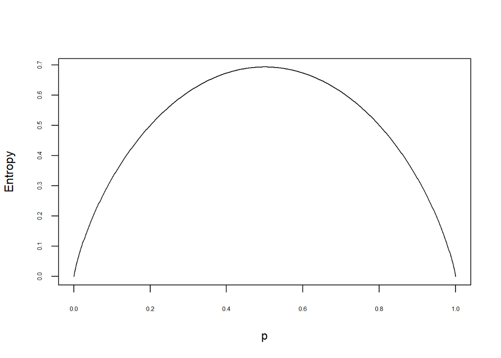

```r
pvals <- seq(0,1000)/1000
ber.ent <- -pvals*log(pvals) - (1-pvals)*log(1-pvals)
ber.ent[1] <- 0
ber.ent[1001] <- 0
plot(ts(ber.ent,start=0,frequency=1000),xlab="p",ylab="Entropy",
    yaxt="n",xaxt="n")
axis(1,cex.axis=.5)
axis(2,cex.axis=.5)
```

## Definition 8.1.12.

- The **differential entropy** of a continuous random variable $X$ is
  $$H(X) = - \int p(x) \, \log ( p(x)) \, dx,$$
  where $p$ is the probability density function.
- We integrate over the support (where $p$ is positive).
- Note that $H(X) = - {\mathbb E} [ \log p (X)]$.
- Can take negative values, but interpretation is the same as discrete case.
- Concepts extends to random vectors by taking the joint pdf.

## Example 8.1.13. Gaussian Entropy

- Suppose $\underline{X}$ is normal with mean zero and $n$-dimensional covariance matrix $\Sigma$, which is assumed to be non-singular. Then
  $$\log p(X) = -\frac{n}{2} \log (2 \pi) - \frac{1}{2} \log \det \Sigma
  - \frac{1}{2} \underline{X}^{\prime} \Sigma^{-1} \underline{X}.$$
- The entropy is the expectation of this times $-1$:
  $$H(X) = \frac{n}{2} \log (2 \pi) + \frac{1}{2} \log \det \Sigma
  + \frac{n}{2},$$
  since ${\mathbb E} [\underline{X}^{\prime} \Sigma^{-1} \underline{X}] = n$ (see Lesson 2-1).

## Exercise 8.4. Poisson Entropy Computation

- We compute the entropy of a Poisson random variable of parameter $\lambda$. The probability mass function is
  $${\mathbb P}[ X = k] = \lambda^k e^{-\lambda}/k!.$$
- The entropy is computed through the following function. This uses a truncation of the infinite summation.

```r
pois.ent <- function(lambda,trunc)
{
    ent <- exp(-lambda)*sum(lambda^(seq(0,trunc))*log(factorial(seq(0,trunc)))/factorial(seq(0,trunc)))
    ent <- ent + lambda*(1 - log(lambda))
    return(ent)
}
```

- We plot the entropy for various $\lambda$, truncating at $50$.

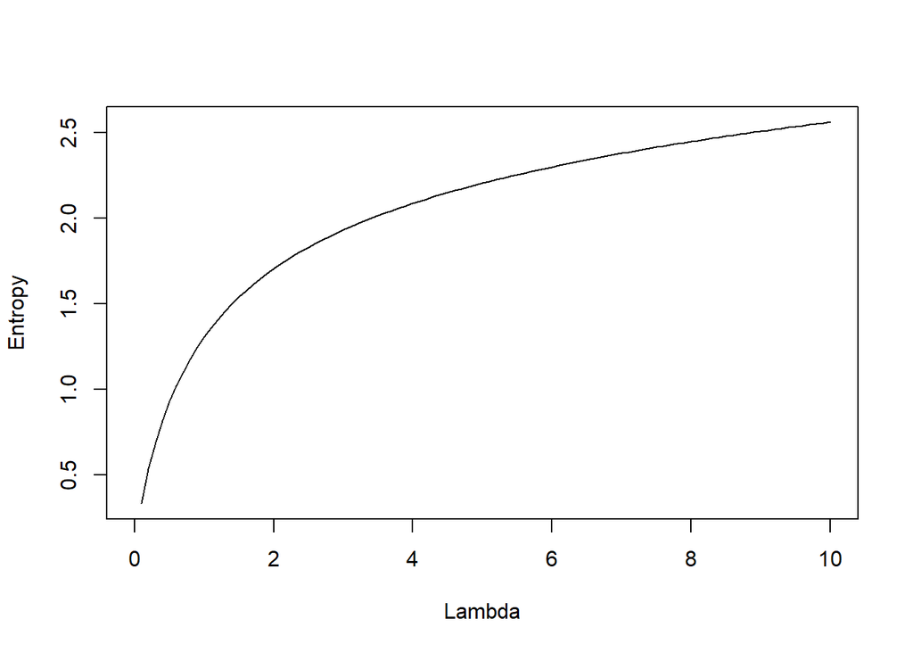

```r
lambda <- seq(0,100)/10
my.ents <- NULL
for(i in 1:length(lambda))
{
    my.ents <- c(my.ents,pois.ent(lambda[i],50))
}
plot(ts(my.ents,start=0,frequency=10),xlab="Lambda",ylab="Entropy")
```